# LSL hands-on:

# What did we learn comparing EEG and Unity data streams?

## 1. Why aligning data streams is important?

Data streaming devices have different:

- Sampling rates
- CPU clocks

[figure not shown]

- Plus: they can be connected via network (LAN or WLAN) -> delays

## 1. Why aligning data streams is important?

Example:

[figure not shown]

## 1. Why aligning data streams is important?

Example:

- Westdrive (Unity): 60 FPS

[figure not shown]

- Toby eye tracker: 90 Hz

[figure not shown]

- TMSI Rega EEG amplifier: 1024 Hz

[figure not shown]

## 2. Delay, latency and jitter

[figure not shown]

Differences:

- Delay: time for some data to move from one endpoint to another
- Latency: one-way delay
- Jitter: delay inconsistency between each packet

Delay contributors:

- Processing: package analysis time
- Queueing: time between being queued and sent
- Transmission: time to push the data into the wire
- Propagation: time influenced by the distance

Source: https://www.callstats.io/blog/2018/03/07/difference-between-jitter-and-latency

## 3. What is LSL (lab streaming layer)?

Two ways of solving the alignment of time series data:

- manually-> more time consuming, but more control
- automatically via soft solution (e.g. LSL) -> less time consuming, less control

Also advantages of LSL:

- open source
- cross platform (Win, Linux, MacOS, Android, iOS)
- multi API language interfaces (C, C++, Python, Java, C#, MATLAB)
- many tools around it
- scientific community support
- XDF stored data

Source: https://labstreaminglayer.readthedocs.io/info/intro.html#what-is-lsl

## 3. What is LSL (lab streaming layer)?

How to use LSL? Requirements:

- LabRecorder app
- liblsl library with code defining your data streams

  and/or
- LSL community app

## 3. What is LSL (lab streaming layer)?

The Lab Recorder (with BIDS support):

[figure not shown]

## 3. What is LSL (lab streaming layer)?

Code example in C# defining a data stream:

```
using LSL;

public class yourClass
{
    private liblsl.StreamInfo lslStreamInfo;
    private liblsl.StreamOutlet lslOutlet;

    void startingMethod() { // normally Start() in Unity
        lslStreamInfo = new liblsl.StreamInfo(
            sName,
            sType,
            nValues,
            nominalRate,
            LslChannelFormat,
            uuid);
        lslOutlet = new liblsl.StreamOutlet(streamInfo);
    }

    void sendingMethod() { // normally FixedUpdate() in Unity
        var data = new float[size];
        lslOutlet.push_sample(data);
    }
}
```

## 4. Designing the test

Situation: Every 500ms a beep sound is played and the background color changes for one frame from black to white.

Unity (90 FPS):

- color change (black or white background)
- 100 ms beep sound (audio playing or not)

EEG (1024 Hz):

- photodiode (light sensor)
- microphone (audio sensor)

Recording setups with different:

- HMDs (Head-mounted display)
- computers (single and two LAN-connected)
- Unity builds
- long and short recordings

## 4. Designing the test

[figure not shown]

## 4. Designing the test

Computers specs:

|  | CPU | GPU | RAM |
| --- | --- | --- | --- |
| **westbrook** | Intel Xeon E5-1607 v4 (4) @ 3.10GHz | NVIDIA GeForce GTX 1070 | 32GB |
| **VR5** | Intel Xeon E5-1630 v3 (8) @ 3.80GHz | NVIDIA GeForce GTX 1080 Ti | 32GB |
| **wd-right** | Intel Xeon W-2133 (12) @ 3.60GHz | NVIDIA GeForce GTX 1080 Ti | 16GB |

[figure not shown]

## 4. Designing the test

Background:

[figure not shown]

Audio:

[figure not shown]

## 5. How did we analyze the data?

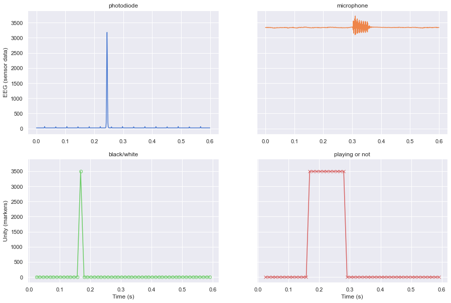

## 5. How did we analyze the data?

[figure not shown]

1. Read the XDF files and select the right data
2. Recalculate the timestamps from 0
3. Visualize the data
4. Timestamps comparison (length, duration, sample count...): file info vs original vs calculated
5. Descriptive statistics of timestamps distributions
6. Peak detections and latency calculations

## 6. Results

How the recordings look like?

|  | eeg_starts | length_unity_audio | length_unity_color | lsl_aligned | two_computers | computers | duration (') |
| --- | --- | --- | --- | --- | --- | --- | --- |
| ftest1 | ✔ | ✔ | ✔ | ✔ | ✗ | westbrook | 2.03 |
| ftest_build1 | ✔ | ✔ | ✔ | ✔ | ✗ | westbrook | 2.08 |
| ftest_lsl12 | ✔ | ✔ | ✔ | ✗ | ✗ | westbrook | 2.21 |
| ftest_build2 | ✔ | ✔ | ✔ | ✔ | ✗ | westbrook | 2.23 |
| ftest3 | ✔ | ✔ | ✔ | ✔ | ✗ | westbrook | 2.28 |
| ftest2 | ✔ | ✔ | ✔ | ✔ | ✗ | westbrook | 2.31 |
| ftest_build3 | ✔ | ✔ | ✔ | ✔ | ✗ | westbrook | 2.43 |
| long2 | ✔ | ✔ | ✔ | ✔ | ✔ | westbrook & VR5 | 30.05 |
| long3 | ✗ | ✔ | ✔ | ✔ | ✔ | westbrook & VR5 | 30.81 |
| long4 | ✔ | ✔ | ✗ | ✔ | ✔ | westbrook & VR5 | 35.68 |
| final_test | ✔ | ✔ | ✔ | ✔ | ✔ | westbrook & wd-right | 65.81 |

## 6. Results

How the recordings look like?

- 4 long recordings (3x 30 minutes + 1x 1 hour)
- 6 short recordings (6x 2 minutes, 2 different unity builds)
- ftest_lsl12 removed from the analysis because timestamps were not aligned

## 6. Results

LSL timestamps: aligned vs not aligned

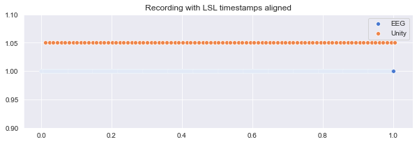

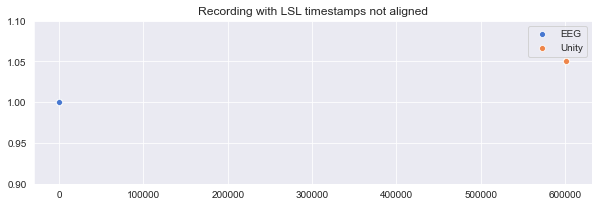

## 6. Results

How does the start of `long2` vs `long3` look like?

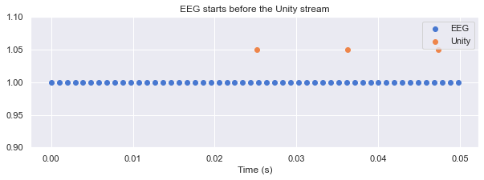

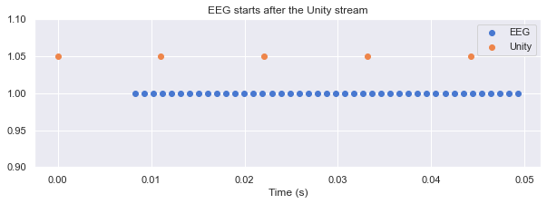

## 6. Results

How constant are the framerates?

**EEG (1024 Hz or sample each ~ 0.98 ms)**

|  | ftest1 | ftest_build1 | ftest_build2 | ftest3 | ftest2 | ftest_build3 | long2 | long3 | long4 | final_test | AVG |
| --- | --- | --- | --- | --- | --- | --- | --- | --- | --- | --- | --- |
| count | 124959.000000 | 128031.000000 | 137247.000000 | 139807.000000 | 141855.000000 | 148511.000000 | 1846271.000000 | 1892831.000000 | 2191839.000000 | 4042655.000000 | 1079400.600000 |
| mean | 0.000977 | 0.000977 | 0.000977 | 0.000977 | 0.000977 | 0.000977 | 0.000977 | 0.000977 | 0.000977 | 0.000977 | 0.000977 |
| std | 0.000000 | 0.000000 | 0.000000 | 0.000000 | 0.000000 | 0.000000 | 0.000000 | 0.000000 | 0.000000 | 0.000000 | 0.000000 |
| min | 0.000977 | 0.000977 | 0.000977 | 0.000977 | 0.000977 | 0.000977 | 0.000977 | 0.000977 | 0.000977 | 0.000977 | 0.000977 |
| 25% | 0.000977 | 0.000977 | 0.000977 | 0.000977 | 0.000977 | 0.000977 | 0.000977 | 0.000977 | 0.000977 | 0.000977 | 0.000977 |
| 50% | 0.000977 | 0.000977 | 0.000977 | 0.000977 | 0.000977 | 0.000977 | 0.000977 | 0.000977 | 0.000977 | 0.000977 | 0.000977 |
| 75% | 0.000977 | 0.000977 | 0.000977 | 0.000977 | 0.000977 | 0.000977 | 0.000977 | 0.000977 | 0.000977 | 0.000977 | 0.000977 |
| max | 0.000977 | 0.000977 | 0.000977 | 0.000977 | 0.000977 | 0.000977 | 0.000977 | 0.000977 | 0.000977 | 0.000977 | 0.000977 |

## 6. Results

How constant are the framerates?

**Unity (90 FPS or sample ~ 11.11 ms)**

|  | ftest1 | ftest_build1 | ftest_build2 | ftest3 | ftest2 | ftest_build3 | long2 | long3 | long4 | final_test | AVG |
| --- | --- | --- | --- | --- | --- | --- | --- | --- | --- | --- | --- |
| count | 10981.000000 | 11206.000000 | 12061.000000 | 12285.000000 | 12465.000000 | 13096.000000 | 162286.000000 | 166381.000000 | 192663.000000 | 355351.000000 | 94877.500000 |
| mean | 0.011110 | 0.011110 | 0.011110 | 0.011111 | 0.011111 | 0.011110 | 0.011110 | 0.011110 | 0.011110 | 0.011110 | 0.011110 |
| std | 0.001141 | 0.001266 | 0.001182 | 0.001209 | 0.001135 | 0.001251 | 0.000844 | 0.000840 | 0.000843 | 0.000912 | 0.001062 |
| min | 0.000023 | 0.000023 | 0.000023 | 0.000023 | 0.000023 | 0.000024 | 0.000022 | 0.000022 | 0.000021 | 0.000022 | 0.000023 |
| 25% | 0.011022 | 0.011026 | 0.011020 | 0.011023 | 0.011022 | 0.011019 | 0.011065 | 0.011065 | 0.011069 | 0.011059 | 0.011039 |
| 50% | 0.011109 | 0.011110 | 0.011111 | 0.011110 | 0.011108 | 0.011111 | 0.011106 | 0.011106 | 0.011106 | 0.011107 | 0.011108 |
| 75% | 0.011195 | 0.011194 | 0.011198 | 0.011194 | 0.011196 | 0.011202 | 0.011148 | 0.011148 | 0.011143 | 0.011155 | 0.011178 |
| max | 0.022469 | 0.022343 | 0.022632 | 0.022717 | 0.022827 | 0.025182 | 0.023186 | 0.023030 | 0.023148 | 0.022965 | 0.023050 |

## 6. Results

How constant are the framerates?

**Unity (90 FPS or sample each 11.11 ms)**

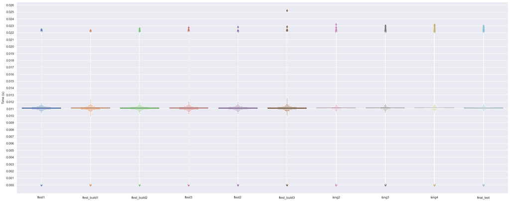

## 6. Results

How constant are the framerates?

**Unity (90 FPS or sample ~ 11.11 ms)**

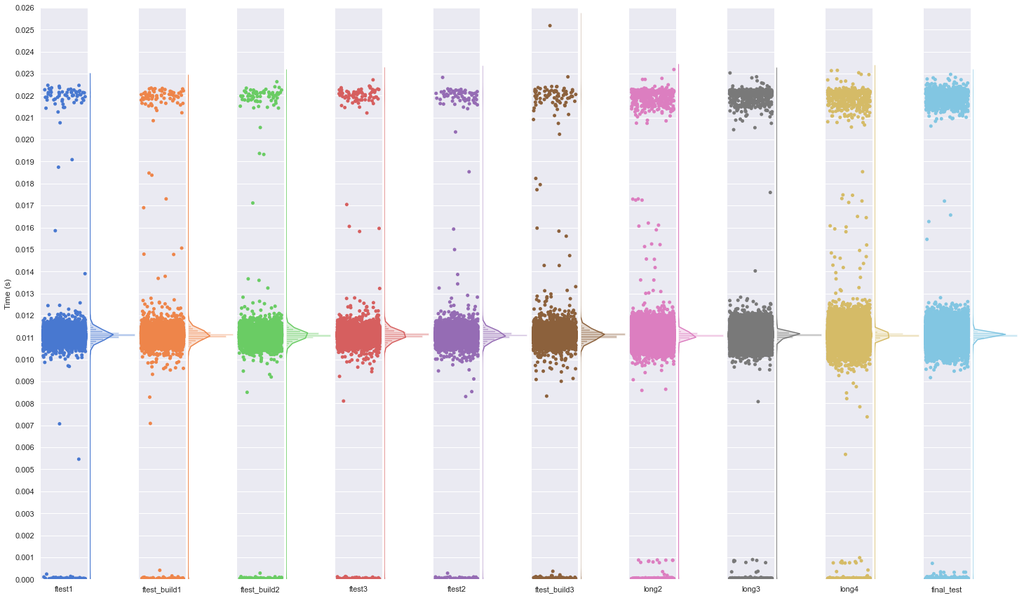

## 6. Results

How constant are the framerates?

**Unity (90 FPS or sample ~ 11.11 ms)**

|  | N | N 0 | % 0 | N Middle | % Middle | N 2x | % 2x | N 2x -> 0 | % 2x -> 0 | N 0 -> 2x | % 0 -> 2x |
| --- | --- | --- | --- | --- | --- | --- | --- | --- | --- | --- | --- |
| ftest1 | 10981 | 62 | 0.56461 | 10843 | 98.74328 | 76 | 0.69210 | 38 | 0.34605 | 25 | 0.22767 |
| ftest_build1 | 11206 | 89 | 0.79422 | 11007 | 98.22417 | 110 | 0.98162 | 53 | 0.47296 | 41 | 0.36588 |
| ftest_build2 | 12061 | 78 | 0.64671 | 11890 | 98.58221 | 93 | 0.77108 | 53 | 0.43943 | 38 | 0.31507 |
| ftest3 | 12285 | 84 | 0.68376 | 12099 | 98.48596 | 102 | 0.83028 | 54 | 0.43956 | 36 | 0.29304 |
| ftest2 | 12465 | 76 | 0.60971 | 12286 | 98.56398 | 103 | 0.82631 | 55 | 0.44124 | 33 | 0.26474 |
| ftest_build3 | 13096 | 103 | 0.78650 | 12859 | 98.19029 | 134 | 1.02321 | 76 | 0.58033 | 62 | 0.47343 |
| long2 | 162286 | 468 | 0.28838 | 161206 | 99.33451 | 612 | 0.37711 | 295 | 0.18178 | 152 | 0.09366 |
| long3 | 166381 | 464 | 0.27888 | 165306 | 99.35389 | 611 | 0.36723 | 312 | 0.18752 | 168 | 0.10097 |
| long4 | 192663 | 631 | 0.32751 | 191124 | 99.20120 | 908 | 0.47129 | 533 | 0.27665 | 253 | 0.13132 |
| final_test | 355351 | 1191 | 0.33516 | 352669 | 99.24525 | 1491 | 0.41959 | 673 | 0.18939 | 420 | 0.11819 |

## 6. Results

Peak detections

|  | maximum | u_color | % u_color | e_color | % e_color | u_audio | % u_audio | e_audio | % e_audio |
| --- | --- | --- | --- | --- | --- | --- | --- | --- | --- |
| ftest1 | 244 | 239 | 97.95082 | 237 | 99.16318 | 239 | 97.95082 | 239 | 100.00000 |
| ftest_build1 | 250 | 244 | 97.60000 | 242 | 99.18033 | 244 | 97.60000 | 244 | 100.00000 |
| ftest_build2 | 268 | 262 | 97.76119 | 258 | 98.47328 | 262 | 97.76119 | 262 | 100.00000 |
| ftest3 | 273 | 268 | 98.16850 | 264 | 98.50746 | 268 | 98.16850 | 267 | 99.62687 |
| ftest2 | 277 | 271 | 97.83394 | 268 | 98.89299 | 271 | 97.83394 | 271 | 100.00000 |
| ftest_build3 | 290 | 286 | 98.62069 | 282 | 98.60140 | 286 | 98.62069 | 284 | 99.30070 |
| long2 | 3606 | 3532 | 97.94786 | 3520 | 99.66025 | 3532 | 97.94786 | 3532 | 100.00000 |
| long3 | 3696 | 3621 | 97.97078 | 3604 | 99.53052 | 3621 | 97.97078 | 3621 | 100.00000 |
| long4 | 4280 | 4195 | 98.01402 | 4172 | 99.45173 | 4195 | 98.01402 | 4195 | 100.00000 |
| final_test | 7895 | 7748 | 98.13806 | 7706 | 99.45792 | 7747 | 98.12540 | 7744 | 99.96128 |

## 6. Results

Peak detections

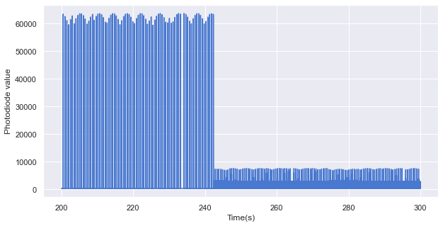

## 6. Results

Latencies

**Time distance between unity color markers and the diode peaks**

|  | ftest1 | ftest_build1 | ftest_build2 | ftest3 | ftest2 | ftest_build3 | long2 | long3 | long4 | final_test | AVG |
| --- | --- | --- | --- | --- | --- | --- | --- | --- | --- | --- | --- |
| count | 237.000000 | 242.000000 | 258.000000 | 264.000000 | 268.000000 | 282.000000 | 3520.000000 | 3604.000000 | 4172.000000 | 7706.000000 | 2055.300000 |
| mean | 0.075043 | 0.075053 | 0.075050 | 0.075026 | 0.075027 | 0.075070 | 0.073522 | 0.073504 | 0.075977 | 0.075361 | 0.074863 |
| std | 0.000495 | 0.000348 | 0.000543 | 0.000507 | 0.000383 | 0.000660 | 0.000365 | 0.000406 | 0.000406 | 0.000301 | 0.000441 |
| min | 0.073792 | 0.074127 | 0.073756 | 0.073762 | 0.072521 | 0.073900 | 0.062520 | 0.062223 | 0.064602 | 0.074084 | 0.070529 |
| 25% | 0.074742 | 0.074797 | 0.074765 | 0.074752 | 0.074783 | 0.074765 | 0.073278 | 0.073266 | 0.075732 | 0.075118 | 0.074600 |
| 50% | 0.075020 | 0.075041 | 0.075039 | 0.075005 | 0.075050 | 0.074964 | 0.073521 | 0.073511 | 0.075978 | 0.075364 | 0.074849 |
| 75% | 0.075293 | 0.075276 | 0.075288 | 0.075263 | 0.075274 | 0.075275 | 0.073777 | 0.073758 | 0.076228 | 0.075610 | 0.075104 |
| max | 0.080321 | 0.076752 | 0.080420 | 0.079667 | 0.077808 | 0.080432 | 0.075394 | 0.077715 | 0.081206 | 0.075989 | 0.078570 |

## 6. Results

Latencies

**Time distance between unity color markers and the diode peaks**

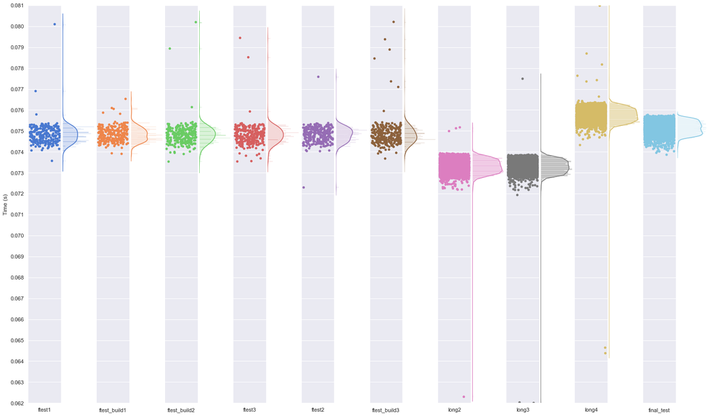

## 6. Results

Latencies

**Time distance between unity audio playing markers and microphone peaks**

|  | ftest1 | ftest_build1 | ftest_build2 | ftest3 | ftest2 | ftest_build3 | long2 | long3 | long4 | final_test | AVG |
| --- | --- | --- | --- | --- | --- | --- | --- | --- | --- | --- | --- |
| count | 239.000000 | 244.000000 | 262.000000 | 267.000000 | 271.000000 | 284.000000 | 3532.000000 | 3621.000000 | 4195.000000 | 7744.000000 | 2065.900000 |
| mean | 0.144945 | 0.139820 | 0.138772 | 0.143700 | 0.145448 | 0.143370 | 0.139008 | 0.143943 | 0.139353 | 0.141953 | 0.142031 |
| std | 0.004377 | 0.004409 | 0.004587 | 0.006956 | 0.005367 | 0.004463 | 0.004401 | 0.004385 | 0.004341 | 0.005379 | 0.004866 |
| min | 0.124942 | 0.128778 | 0.127420 | 0.125329 | 0.126975 | 0.131950 | 0.125599 | 0.126703 | 0.125724 | 0.125079 | 0.126850 |
| 25% | 0.141982 | 0.136593 | 0.135626 | 0.139428 | 0.141689 | 0.140020 | 0.135901 | 0.140924 | 0.136362 | 0.138423 | 0.138695 |
| 50% | 0.145270 | 0.139689 | 0.138773 | 0.144235 | 0.145351 | 0.143312 | 0.139070 | 0.144048 | 0.139267 | 0.141960 | 0.142098 |
| 75% | 0.148013 | 0.142652 | 0.141839 | 0.147746 | 0.148775 | 0.147163 | 0.142038 | 0.146843 | 0.142362 | 0.145502 | 0.145293 |
| max | 0.157813 | 0.152345 | 0.154999 | 0.171731 | 0.174338 | 0.155167 | 0.157790 | 0.164417 | 0.156623 | 0.173781 | 0.161900 |

## 6. Results

Latencies

**Time distance between unity audio playing markers and microphone peaks**

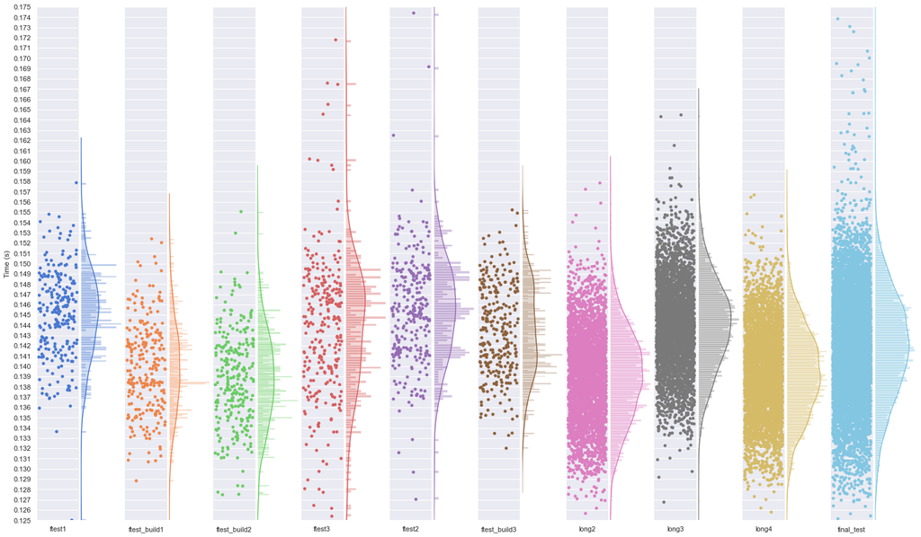

## 8. Future outlook

- New recordings and data analysis using a "heavy" Unity project
- Try very short click sounds for a better estimation of audio latency

## Resources

- [Liblsl](https://github.com/sccn/liblsl/releases)
- [LabRecorder](https://github.com/labstreaminglayer/App-LabRecorder/releases)
- LSL4Unity
- [LSL Apps](https://github.com/sccn/labstreaminglayer/tree/master/Apps)
- [LSL documentation reference](https://labstreaminglayer.readthedocs.io/)
- [LSL latency analysis](https://github.com/mvidaldp/lsl_latency_analysis)
- [Unity latency project](https://github.com/mvidaldp/black_n_white)
- [Audio tones generator](https://github.com/mvidaldp/pytonegen)